# TP CUSUM

Erivan INAN, M2 ISDS, 2025

```
                                                           TP CUSUM
```

**————————————————————– IMPORTATION DES LIBRAIRIES NÉCESSAIRES ————————————————————-**

```r
# bibliothèques nécessaires
library(ggplot2) # Pour l'affichage des graphes
library(qcc) # Pour les cartes de contrôle
```

**————————————————————————————— EXERCICE 1 ————————————————————————————–**

```r
# Données de l'énoncé
data1 <- c(1045, 1055, 1037, 1064, 1095, 1008, 1050, 1087, 1125, 1146,
                  1139, 1169, 1151, 1128, 1238, 1125, 1163, 1188, 1146, 1167)
```

**Question 1** Carte de contrôle CUSUM

La carte CUSUM permet de détecter de petites variations dans la moyenne du processus en cumulant les écarts par rapport à la valeur de référence $\mu_0 = 1050$. Elle repose sur les statistiques suivantes :

$$C^+_l = \max(0, x_l - (1050 + K) + C^+_{l-1})$$

$$C^-_l = \max(0, (1050 + K) - x_l + C^-_{l-1})$$

avec :

$$C^+_0 = C^-_0 = 0$$

et où la valeur de référence $K$ est définie comme :

$$K = \frac{| \mu_1 - \mu_0 |}{2} = \frac{| \mu_1 - 1050 |}{2}$$

Dans notre cas, nous considérons un écart-type sous contrôle de $\sigma_0 = 25$. Les seuils de décision sont définis comme :

$$H = h \times \sigma_0$$

Dans notre exercice, nous avons $h = 5$, donc :

$$H = 5 \times 25 = 125$$

Dans la fonction **`cusum()`** du package `qcc` en R, le paramètre `decision.interval` est exprimé en multiple de l’écart-type. On a la relation suivante :

$$H = \text{decision.interval} \times \sigma_0$$

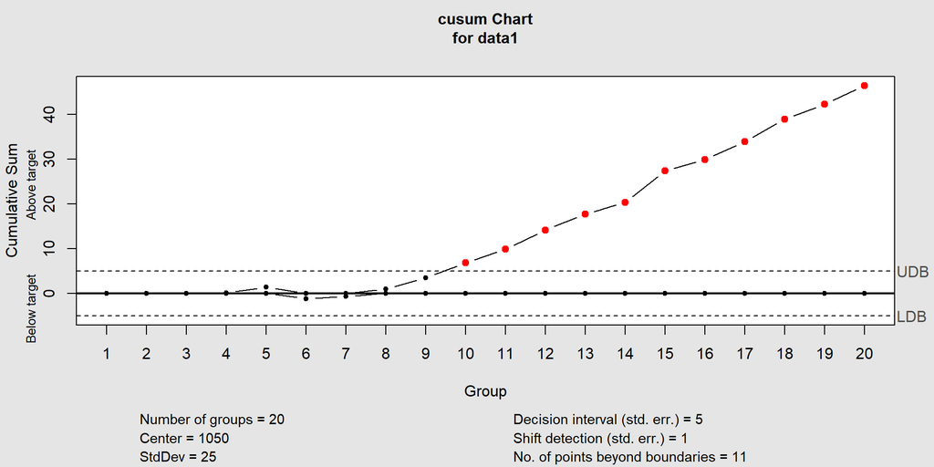

```r
# Paramètres donnés
mu0 <- 1050 # Moyenne sous contrôle
sigma0 <- 25 # Écart-type sous contrôle

# Affichage de la carte
cusum_chart <- cusum(data1, center = mu0, std.dev = sigma0, decision.interval = 5, se.shift = 1)
plot(cusum_chart, main = "Carte CUSUM")
```

Jusqu’à la 8ème observation, les valeurs restent proches de zéro, indiquant que le processus est sous contrôle. À partir de la 9ème observation, il y a une augmentation progressive des écarts par rapport à la moyenne de référence sous contrôle de 1050. Ceci se voit aussi via les points rouges qui dépassent les seuils de décision et signalent une variation systématique dans le processus.

Pour approfondir cette analyse, il serait pertinent d’examiner une carte EWMA afin de confirmer cette tendance et d’identifier d’éventuelles mesures correctives à mettre en place pour ramener le processus sous contrôle.

**Question 2** Carte de contrôle EWMA

La carte Exponentially Weighted Moving Average (EWMA) est conçue pour détecter les variations progressives du processus en attribuant un poids exponentiellement décroissant aux observations passées. Elle est faite pour détecter de très petits changements.

La statistique utilisée est définie comme suit dans le cours, adapté aux valeurs de notre exercice :

$$Z_l = \lambda x_l + (1 - \lambda) Z_{l-1}$$

où :

- $\lambda = 0.10$ est le facteur de lissage,
- $Z_0 = 1050$ est la moyenne initiale sous contrôle.

Les limites de contrôle sont données par :

$$UCL = 1050 + 2.7 \times \sigma_0 \sqrt{\frac{\lambda}{2 - \lambda} (1 -
(1 - \lambda)^{2l})}$$

$$LCL = 1050 - 2.7 \times \sigma_0 \sqrt{\frac{\lambda}{2 - \lambda} (1 -
(1 - \lambda)^{2l})}$$

Dans le package `qcc` en R, nous utilisons la fonction `ewma()` pour construire cette carte :

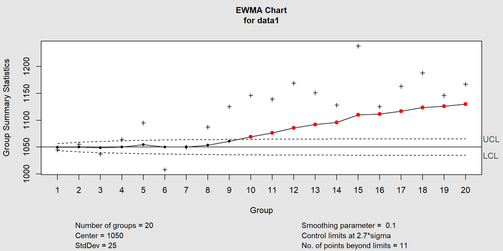

```r
lambda <- 0.1 # Paramètre de lissage
L <- 2.7 # Facteur de contrôle

# Affichage de la carte
ewma_chart <- ewma(data1, center = mu0, std.dev = sigma0, lambda = lambda, nsigmas = L)
plot(ewma_chart, main = "Carte EWMA")
```

Cette nouvelle carte EWMA confirme l’augmentation observée sur la carte CUSUM, ici de la moyenne pondérée des observations au cours du temps.

Au-delà de la 9ème observation, les valeurs commencent à s’éloigner progressivement vers le haut, et plusieurs points dépassent la limite de contrôle supérieure, ce qui signale un changement significatif dans le processus. Comme dans la carte CUSUM, 11 points se situent en dehors des limites de contrôle.

Contrairement à la carte CUSUM, la carte EWMA présente une évolution plus lisse grâce au paramètre de lissage de 0.1 qui permet de détecter progressivement les variations. De plus, CUSUM met en évidence la somme cumulative des écarts tandis que EWMA attribue un poids plus important aux valeurs récentes.

**Question 3** Carte de contrôle MA

La carte de contrôle Moyenne Mobile (MA) est une technique utilisée pour suivre l’évolution du processus en calculant la moyenne des observations sur une fenêtre glissante de taille $w$. Contrairement à la carte EWMA, qui applique un lissage exponentiel, la carte MA utilise une moyenne non pondérée sur une fenêtre d’observations successives.

La formule de la moyenne mobile est définie par :

$$M_l = \frac{x_l + x_{l-1} + \dots + x_{l-w+1}}{w}$$

où : - $M_l$ est la moyenne mobile à l’instant $l$, - $x_l$ est l’observation actuelle, - $w$ est la taille de la fenêtre de lissage.

Dans notre cas, nous avons : - $w = 6$ (fenêtre de 6 observations successives) - $\mu_0 = 1050$ (moyenne sous contrôle) - $\sigma_0 = 25$ (écart-type sous contrôle)

Ainsi, toute moyenne mobile qui dépasse ces bornes indique une dérive potentielle du processus.

La carte MA peut être implémentée en R à l’aide de la fonction `filter()` du package `stats`, qui applique un lissage en utilisant une moyenne mobile sur une fenêtre donnée.

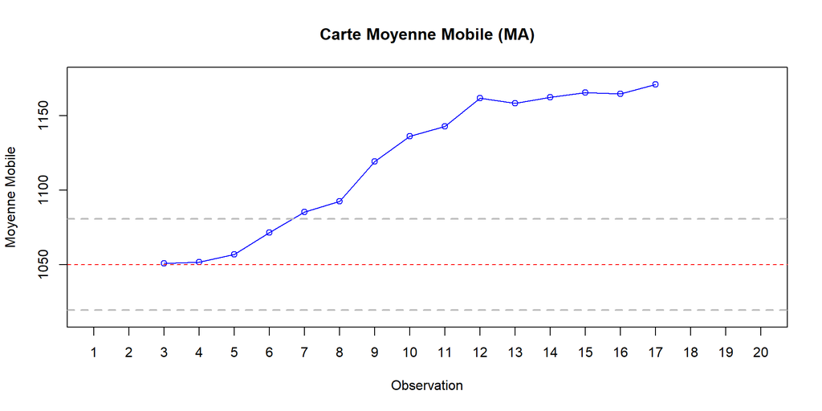

```r
w <- 6         # Taille de la fenêtre pour la moyenne mobile

# Calcul de la moyenne mobile
moving_avg <- filter(data1, rep(1/w, w), sides = 2)

# Calcul des limites de contrôle
UCL <- mu0 + 3 * sigma0 / sqrt(w)
LCL <- mu0 - 3 * sigma0 / sqrt(w)


# Affichage de la carte
plot(moving_avg, type = "o", col = "blue", main = "Carte Moyenne Mobile (MA)",
     xlab = "Observation", ylab = "Moyenne Mobile", xaxt = "n",
     ylim = c(min(LCL, min(moving_avg, na.rm = TRUE)) - 5,
              max(UCL, max(moving_avg, na.rm = TRUE)) + 5))

axis(1, at = 1:length(data1), labels = 1:length(data1)) # pour graduer les abscisses

abline(h = UCL, col = "gray", lty = 2, lwd = 2)
abline(h = LCL, col = "gray", lty = 2, lwd = 2)

abline(h = mu0, col = "red", lty = 2)
```

La carte Moyenne Mobile (MA) montre une augmentation progressive des valeurs moyennes à partir de la 7ème observation.

Cette tendance est cohérente avec la carte CUSUM, qui montrait une accumulation progressive des écarts après la 9ème observation. La carte CUSUM détectait une dérive dès les premières observations légèrement supérieures à la moyenne, tandis que la carte MA met en évidence une augmentation continue sur une fenêtre plus large. Le processus peut avoir subi une modification ne semblant pas être simplement due à des fluctuations aléatoires.

Contrairement à la carte CUSUM, qui est plus sensible aux petits écarts cumulés, la carte MA lisse davantage les variations. Ainsi, en combinant les deux approches, nous obtenons une validation robuste du fait que le processus s’est éloigné de l’état de contrôle.

**————————————————————————————— EXERCICE 2 ————————————————————————————–**

**Question 1** :

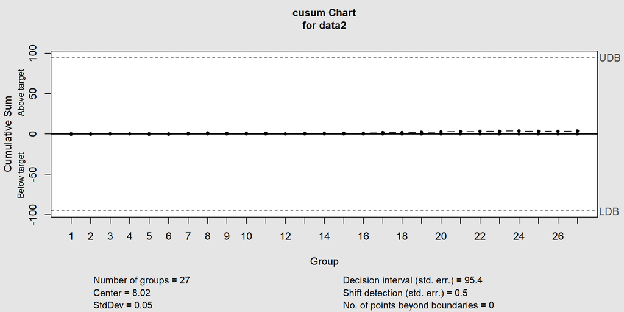

```r
data2 <- c(8.00, 8.01, 8.02, 8.01, 8.00, 8.01, 8.06, 8.07, 8.01, 8.04, 8.02, 8.01,
                  8.05, 8.04, 8.03, 8.05, 8.06, 8.04, 8.05, 8.06, 8.04, 8.06, 8.04, 8.04, 8.02, 8.03, 8.05)

# Paramètres
mu <- 8.02 # valeur cible
sigma <- 0.05 # écart-type hypothétique

# Affichage de la carte
carte_cusum <- cusum(data2, center = mu, std.dev = sigma, decision.interval = 4.77 / sigma, se.shift = 0.5)

plot(carte_cusum, main = "Carte CUSUM Classique")
```

**Question 2** :

Estimons l’écart-type réel des observations via la formule ci-dessous et comparons le à la valeur supposée :

```r
sigma_estime <- sd(data2) # Écart-type empirique
cat("Écart-type estimé :", sigma_estime, "\n")
```

```
## Écart-type estimé : 0.02061726
```

On peut également réaliser un test statistique sur la variance, en posant les hypothèses suivantes :

$$H_0: \sigma = 0.05 \quad \text{et} \quad H_1: \sigma \neq 0.05$$

```r
var_test <- var.test(data2, rep(0.05^2, length(data2)))
print(var_test)
```

```
##
##  F test to compare two variances
##
## data:  data2 and rep(0.05^2, length(data2))
## F = Inf, num df = 26, denom df = 26, p-value < 2.2e-16
## alternative hypothesis: true ratio of variances is not equal to 1
## 95 percent confidence interval:
##  Inf Inf
## sample estimates:
## ratio of variances
##                Inf
```

**Question 3** :

La carte CUSUM repose sur le calcul des sommes cumulées pour détecter des écarts par rapport à la moyenne. Les statistiques de contrôle utilisées sont :

$$C^+_l = \max(0, C^+_{l-1} + (x_l - \mu_0) - k\sigma_0)$$

$$C^-_l = \max(0, C^-_{l-1} - (x_l - \mu_0) - k\sigma_0)$$

avec :

$$C^+_0 = C^-_0 = 0.$$

Lorsque l’une des statistiques $C^+_l$ ou $C^-_l$ dépasse le seuil de décision $h$, une alarme est déclenchée indiquant une potentielle dérive du processus.

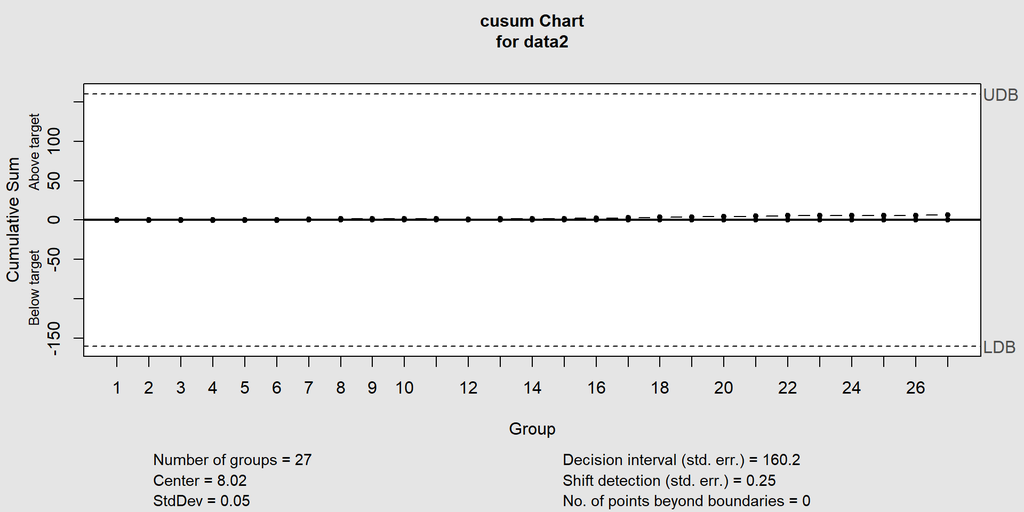

```r
sigma = 0.05 # variance hypothétique

cusum_standardisee <- cusum(data2, center = mu, std.dev = sigma, decision.interval = 8.01 / sigma, se.shift = 0.25)
plot(cusum_standardisee, main = "Carte CUSUM Standardisée")
```

**Question 4** Comparaison des résultats :

La carte CUSUM standardisée montre que toutes les observations restent bien en dessous des seuils de contrôle. Aucun dépassement n’est détectée, le processus est sous contrôle. Cependant, voyons les éléments suivants :

L’augmentation de $h$ (passant à 8.01) et la réduction de $k$ (à 0.25) rendent la carte standardisée plus conservatrice, ce qui signifie qu’elle réagit moins rapidement aux petits écarts du processus. De plus, l’intervalle de décision est beaucoup plus large que dans la carte CUSUM classique ($160.2$ contre $95.4$), ce qui renforce encore cette inertie dans la détection des variations.

Le principal problème vient du choix de l’écart-type supposé $\sigma = 0.05$, alors que l’estimation empirique donne $\hat{\sigma} = 0.0206$. Avec une valeur de $\sigma$ surestimée, les limites de contrôle sont trop larges et empêchent la détection de petites dérives.

Pour conclure, cette carte, bien que fonctionnelle, est trop peu sensible aux faibles écarts. Une mise à jour des paramètres en intégrant l’écart-type empirique permettrait une meilleure réactivité et une surveillance plus efficace du processus.

**Question 5** Discussion du choix de $h$ et $k$ :

Le paramètre $k$ représente le seuil de détection en dessous duquel les variations sont considérées comme des fluctuations normales du processus. Les variations au dessus de ce seuil sont cumulées dans la carte CUSUM.

Le paramètre $h$ définit l’intervalle de décision, et le seuil à partir duquel la somme cumulative dépasse le seuil de contrôle.

Comment varient ces paramètres ?

- Plus $k$ est grand, moins la carte est sensible aux petites variations, comme observé en question 1.
- Plus $h$ est grand, plus la carte est tolérante aux écarts et la détection est ralentie.

Dans notre exercice, la carte standardisée utilise un $h$ plus élevé, ce qui diminue la probabilité de dépasser le seuil de détection. Avec un $h = 8.01$ et un $k = 0.25$, cette carte privilégie la réduction des fausses alertes au détriment de la rapidité de détection.

**Question 6** :

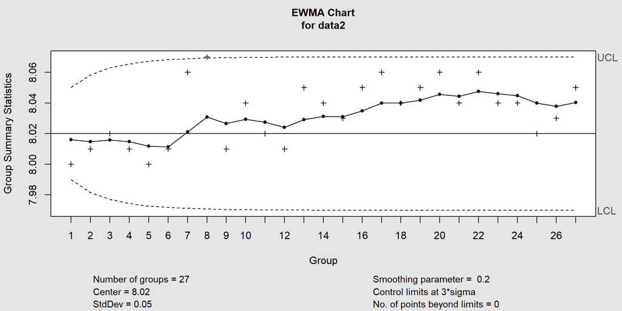

```r
# Paramètres
mu0 <- 8.02 # moyenne sous contrôle
sigma <- 0.05 # écart-type supposé
lambda <- 0.2 # facteur de lissage
L <- 3 # facteur de contrôle

# Affichage de la carte
ewma_chart <- ewma(data2, center = mu0, std.dev = sigma, lambda = lambda, nsigmas = L)
plot(ewma_chart, main = "Carte de contrôle EWMA", col = "blue")
```

Toutes les observations restent à l’intérieur des limites de contrôle. Aucun point ne dépasse les seuils, ce qui indique que le processus semble sous contrôle. Le point individuel 8 se situe sur la limire UCL mais ne représente pas la moyenne pondérée, il y a donc des variations individuelles dans le processus mais elles ne font pas dévier le processus global.

**Question 7** :

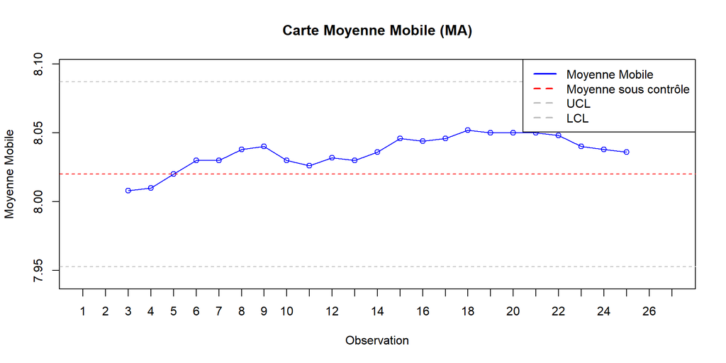

```r
# Paramètres
mu0 <- 8.02 # moyenne sous contrôle
sigma <- 0.05 # écart-type hypothétique
w <- 5 # fenêtre de la moyenne mobile

# calcul de la moyenne mobile
moving_avg <- filter(data2, rep(1/w, w), sides = 2)

# calcul des limites de contrôle
UCL <- mu0 + 3 * sigma / sqrt(w)
LCL <- mu0 - 3 * sigma / sqrt(w)

# Affichage de la carte
plot(moving_avg, type = "o", col = "blue", main = "Carte Moyenne Mobile (MA)",
     xlab = "Observation", ylab = "Moyenne Mobile", xaxt = "n",
     ylim = c(min(LCL, min(moving_avg, na.rm = TRUE)) - 0.01,
              max(UCL, max(moving_avg, na.rm = TRUE)) + 0.01))

axis(1, at = 1:length(data2), labels = 1:length(data2))
abline(h = mu0, col = "red", lty = 2)  # Ligne centrale
abline(h = UCL, col = "gray", lty = 2)  # UCL
abline(h = LCL, col = "gray", lty = 2)  # LCL

legend("topright", legend = c("Moyenne Mobile", "Moyenne sous contrôle", "UCL", "LCL"),
       col = c("blue", "red", "gray", "gray"), lty = c(1, 2, 2, 2), lwd = c(2, 2, 2, 2))
```

Dans les deux cartes, aucun point ne dépasse les limites de décision. Cependant, on peut noter des différences dans la sensibilité aux variations. CUSUM est totalement stable jusqu’à la 16ème observation et elle n’augmente par la suite que légèrement. Le choix de $k$ grand joue un rôle là dedans, comme décrit en question 5. De plus, CUSUM est conçue pour accumuler les écarts successifs par rapport à la moyenne cible. Cette accumulation permet de détecter les écarts systématiques, or dans notre data, les variations semblent faibles et progressives.

Contrairement à CUSUM, MA ne suit pas le cumul des écarts mais lisse les variations sur la fenêtre glissante. Elle met mieux en évidence les tendances lentes, qui peuvent ne pas être perçues par CUSUM si les seuils sont mal calibrés (dans notre cas, c’est $k$ qui est trop grand), mais MA est cependant plus lente à réagir aux changements soudains, car chaque nouvelle valeur influence progressivement la moyenne calculée.

**————————————————————————————— EXERCICE 3 ————————————————————————————–**

Montrons que pour $\lambda = \frac{2}{w+1}$ où $w$ est la taille de la fenêtre de la moyenne mobile, les cartes MA et EWMA sont équivalentes en régime stationnaire.

**Carte MA en régime stationnaire** :

La moyenne mobile d’ordre $w$ est définie comme la moyenne arithmétique des $w$ dernières observations : :

$$M_i = \frac{1}{w} \sum_{l=0}^{w-1} x_{t-i}$$

**Carte EWMA en régime stationnaire** :

La statistique EWMA est définie par :

$$Z_i = \lambda x_i + (1 - \lambda) Z_{i-1}$$

où :

- $\lambda$ est le facteur de lissage
- $Z_0 = \mu_0$ est la moyenne sous contrôle initiale.

Lorsque $n \to \infty$, la récurrence peut s’écrire sous forme de somme pondérée :

$$Z_i = \sum_{l=0}^{\infty} (1 - \lambda)^l \lambda x_{i-l}$$

Les poids suivent une exponentielle décroissante, permettant de donner plus d’importance aux observations récentes.

**Démontrons l’équivalence** :

On commence par développer $Z_i$ par récurrence et on obtient :

$$Z_i = \lambda \sum_{l=0}^{\infty} (1- \lambda)^l x_{i-l}$$

De plus, la somme des poids converge, on a $\lambda \sum_{l=0}^{\infty} (1- \lambda)^l = 1$.

En substituant $\lambda = \frac{2}{w+1}$ dans EWMA :

$$Z_i = \frac{2}{w+1} x_i + (1 - \frac{2}{w+1} ) Z_{i-1}$$

En développant par récurrence $Z_i$, on a :

$$Z_i = \frac{2}{w+1} \sum_{l=0}^{\infty} (1 - \frac{2}{w+1} )^l x_{i-l}$$

En posant $(1 - \frac{2}{w+1}) = \frac{w-1}{w+1}$, on a :

$$Z_i = \frac{2}{w+1} \sum_{l=0}^{\infty} (\frac{w-1}{w+1})^l x_{i-l}$$

**En régime stationnaire, $n \longrightarrow \infty$** :

En se limitant à la somme des $w$ dernières observations (car les poids pour $i \geq w$ sont négligeables), on a :

$$(\frac{w-1}{w+1})^l \approx 1$$
car $\frac{w-1}{w+1} \longrightarrow 1$

Ainsi, les poids appliqués par EWMA aux $w$ dernières observations deviennent quasi constants.

**Conclusion** :

Chaque observation de MA appartenant à la fenêtre $w$ possède un poids valant $\frac{1}{w}$.

De même, quand $\lambda = \frac{2}{w+1}$ et $w \longrightarrow \infty$, les poids appliqués aux observations de EWMA sont quasi constants et valent $\frac{1}{w}$

Finalement, en régime stationnaire, c’est-à-dire lorsque $n \longrightarrow \infty$, on a :

$$Z_i \approx M_i$$

Nous avons démontré que lorsque $\lambda = \frac{2}{w+1}$, la somme des poids dans la carte EWMA est équivalente à celle de la carte MA sur une fenêtre de taille $w$. Ainsi, en régime stationnaire ($n \to \infty$), la carte EWMA se comporte comme une carte Moyenne Mobile, confirmant leur équivalence sous cette condition.

**————————————————————————————— EXERCICE 4 ————————————————————————————–**

**Problème** : On souhaite construire une carte de contrôle d’acceptation adaptée au procédé de fabrication suivant : sous contrôle, la proportion de non-conformité est égale à 0.1%, ce que la direction accepte 95% du temps. Si cette proportion augmente à 2%, la direction souhaite le détecter avec une probabilité égale à 0.90.

Commençons par déterminer la taille d’échantillon optimale $n$ et le nombre maximal de non-conformités acceptées $c$. Pour ce faire, on programme la fonction `calcul_param` qui consiste en une double boucle :

- La boucle externe `for (taille in seq(10, 500))` teste différentes tailles d’échantillons $n$ comprises entre 10 et 500.
- La boucle interne for `(seuil in seq(0, taille))` explore les différentes valeurs possibles du seuil $c$, représentant le nombre maximal de non-conformités acceptées.

À chaque itération, deux conditions sont vérifiées :

```r
# Paramètres
taux_non_conforme_accept <- 0.001  # proportion acceptable de non-conformité
taux_non_conforme_critique <- 0.02   # proportion critique de non-conformité
risque_alpha <- 0.05  # risque d'erreur de première espèce (faux positifs)
risque_beta <- 0.10   # risque d'erreur de seconde espèce (faux négatifs)

# Fonction pour déterminer n et c optimaux
calcul_param <- function(p0, p1, alpha, beta) {
  for (taille in seq(10, 500)) { # Recherche de n
    for (seuil in seq(0, taille)) {  # Recherche de c
      #  Acceptation sous p0 >= 0.95
      if (pbinom(seuil, taille, p0) >= 1 - alpha &&
          #  Détection sous p1 >= 0.90
          1 - pbinom(seuil, taille, p1) >= 1 - beta) {
        return(list(taille = taille, seuil = seuil))
      }
    }
  }
  return(NULL) # si aucune solution trouvée
}

# Exécution de la recherche
resultat <- calcul_param(taux_non_conforme_accept,
                                       taux_non_conforme_critique,
                                       risque_alpha,
                                       risque_beta)

# Résultats
cat("Taille d'échantillon optimale n =", resultat$taille, "\n")
```

```
## Taille d'échantillon optimale n = 194
```

```r
cat("Nombre maximum de non-conformités acceptées c =", resultat$seuil, "\n")
```

```
## Nombre maximum de non-conformités acceptées c = 1
```

Une fois les paramètres optimaux trouvés, on affiche la carte de contrôle avec la librairie `qcc` :

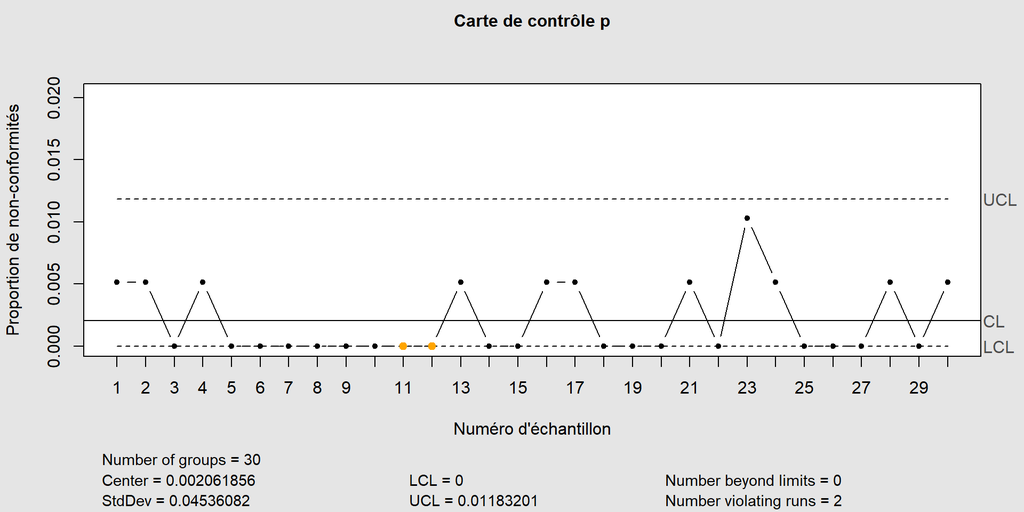

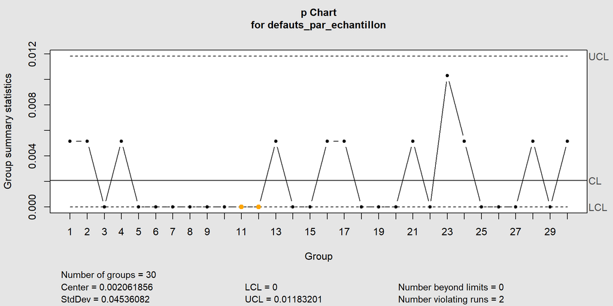

```r
# Paramètres
taille_echantillon <- resultat$taille  # taille d'échantillon trouvée
p0 <- taux_non_conforme_accept  # taux de non-conformité nominal
nb_echantillons <- 30  # nombre d'échantillons à surveiller

# on génère un nombre de non-conformités par échantillon
set.seed(42)
defauts_par_echantillon <- rbinom(nb_echantillons, taille_echantillon, p0)

# Affichage de la carte
carte_controle <- qcc(defauts_par_echantillon,
               sizes = taille_echantillon,
               type = "p",
               labels = 1:nb_echantillons,
               title = "Carte de contrôle p",
               xlab = "Numéro d'échantillon",
               ylab = "Proportion de non-conformités",
               ylim = c(0, max(defauts_par_echantillon / taille_echantillon) + 0.01))

plot(carte_controle)
```

La majorité des points sont bien en dessous de la limite supérieure de contrôle et au dessus de la limite inférieure de contrôle. Certaines fluctuations sont observées, mais elles restent dans les limites acceptables. Il y a quelques pics plus élevés, par exemple autour du point 23, mais aucun ne dépasse les limites.

**————————————————————————————— EXERCICE 5 ————————————————————————————–**

**Question 1** :

```r
# librairie pour le test ADF d'autocorrélation
library(tseries)
```

[output not shown]

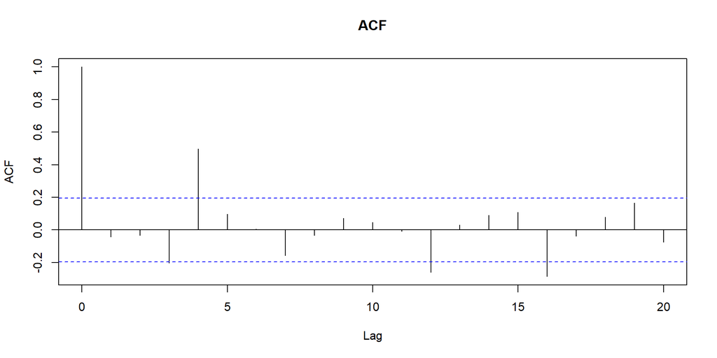

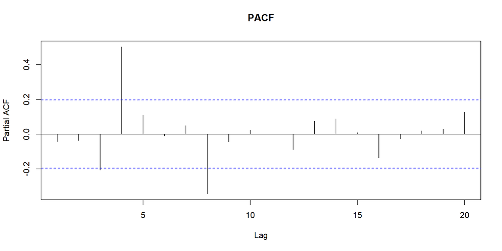

```r
# données fig 5
data5 <- c(
  29.330, 33.220, 27.990, 24.280,
  19.980, 31.150, 24.130, 22.690,
  25.760, 27.080, 29.200, 26.600,
  29.000, 33.660, 34.300, 28.860,
  31.030, 36.580, 26.410, 28.270,
  32.680, 29.040, 28.780, 28.170,
  33.560, 28.080, 21.280, 28.580,
  27.500, 30.280, 21.710, 30.760,
  26.750, 29.350, 21.470, 30.620,
  30.550, 33.600, 24.710, 20.840,
  28.940, 30.290, 33.610, 16.560,
  28.500, 20.110, 36.540, 25.230,
  28.190, 17.510, 35.700, 31.790,
  26.130, 23.710, 33.680, 32.520,
  27.790, 24.220, 29.290, 30.280,
  27.630, 32.430, 25.120, 26.140,
  29.890, 32.440, 27.230, 19.030,
  28.180, 29.390, 30.610, 24.340,
  26.650, 23.450, 29.060, 31.530,
  30.010, 23.620, 28.480, 31.950,
  30.800, 28.120, 32.010, 31.680,
  30.450, 29.940, 31.890, 29.100,
  36.610, 30.560, 31.720, 23.150,
  31.400, 32.300, 29.090, 26.740,
  30.830, 31.580, 31.920, 32.440
)

# test ADF d’auto-corrélation
test_adf <- adf.test(data5)
acf(data5, main="ACF")
pacf(data5, main="PACF")
print(test_adf)
```

[output not shown]

**Question 2** :

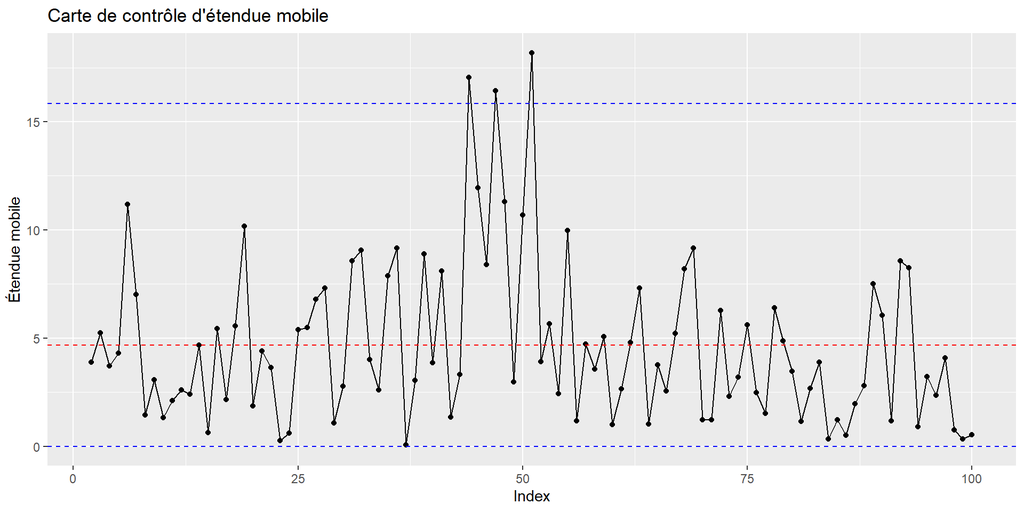

```r
#Carte de contrôle d’étendue mobile
etendue_mobile <- abs(diff(data5))
moyenne_etendue <- mean(etendue_mobile)
ectype_etendue <- sd(etendue_mobile)

ucl <- moyenne_etendue + 3 * ectype_etendue
lcl <- max(moyenne_etendue - 3 * ectype_etendue, 0)  # LCL ne peut pas être négatif

df <- data.frame(Index = 2:length(data5), EtendueMobile = etendue_mobile)

ggplot(df, aes(x = Index, y = EtendueMobile)) +
  geom_line() +
  geom_point() +
  geom_hline(yintercept = moyenne_etendue, color = "red", linetype = "dashed") +
  geom_hline(yintercept = ucl, color = "blue", linetype = "dashed") +
  geom_hline(yintercept = lcl, color = "blue", linetype = "dashed") +
  ggtitle("Carte de contrôle d'étendue mobile") +
  xlab("Index") + ylab("Étendue mobile")
```

La carte de contrôle d’étendue mobile met en évidence une forte variabilité au sein du processus, avec des fluctuations marquées et plusieurs valeurs qui dépassent les limites de contrôle. Un pic important autour de l’index 50 suggère une phase d’instabilité qui pourrait résulter d’un changement dans les conditions du processus.

La présence d’une auto-corrélation (prouvée en question 1) peut expliquer en partie les fluctuations observées sur la carte de contrôle d’étendue mobile, notamment la phase d’instabilité autour de l’index 50. En effet, si un processus est auto-corrélé, les variations passées influencent directement les variations futures, ce qui peut amplifier des phases de dérive ou des tendances temporaires.

**Question 3** :

On suppose que les observations ne sont pas corrélées.

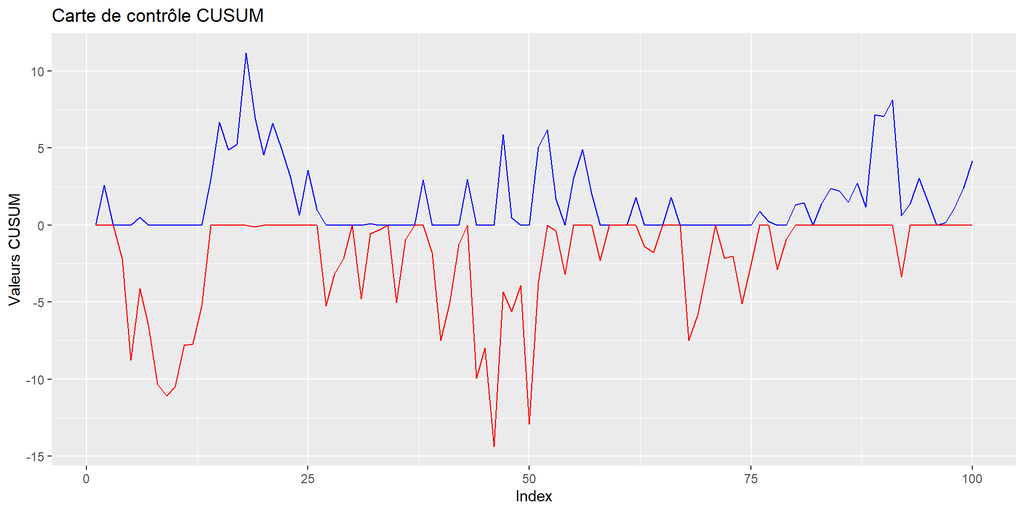

```r
# Carte CUSUM
moy_cusum <- mean(data5)
ectype_cusum <- sd(data5)
k <- 0.5 * ectype_cusum  # valeur de référence
h <- 5 * ectype_cusum  # seuil de détection

cusum_pos <- numeric(length(data5))
cusum_neg <- numeric(length(data5))

for (i in 2:length(data5)) {
  cusum_pos[i] <- max(0, cusum_pos[i-1] + (data5[i] - moy_cusum - k))
  cusum_neg[i] <- min(0, cusum_neg[i-1] + (data5[i] - moy_cusum + k))
}

df_cusum <- data.frame(Index = 1:length(data5), CUSUM_Pos = cusum_pos, CUSUM_Neg = cusum_neg)

ggplot(df_cusum, aes(x = Index)) +
  geom_line(aes(y = CUSUM_Pos), color = "blue") +
  geom_line(aes(y = CUSUM_Neg), color = "red") +
  ggtitle("Carte de contrôle CUSUM") +
  xlab("Index") +
  ylab("Valeurs CUSUM")
```

Comme les observations sont auto-corrélées, les fluctuations pourraient être amplifiées. Dans ce cas, il est pertinent d’ajuster les paramètres de la carte ou d’appliquer une correction pour l’auto-corrélation.

Pour confirmer ces observations, une analyse complémentaire avec une carte EWMA pourrait est pertinente afin de mieux caractériser l’évolution du processus.

**Question 4** : Carte de contrôle EWMA, $\lambda = 0.15$

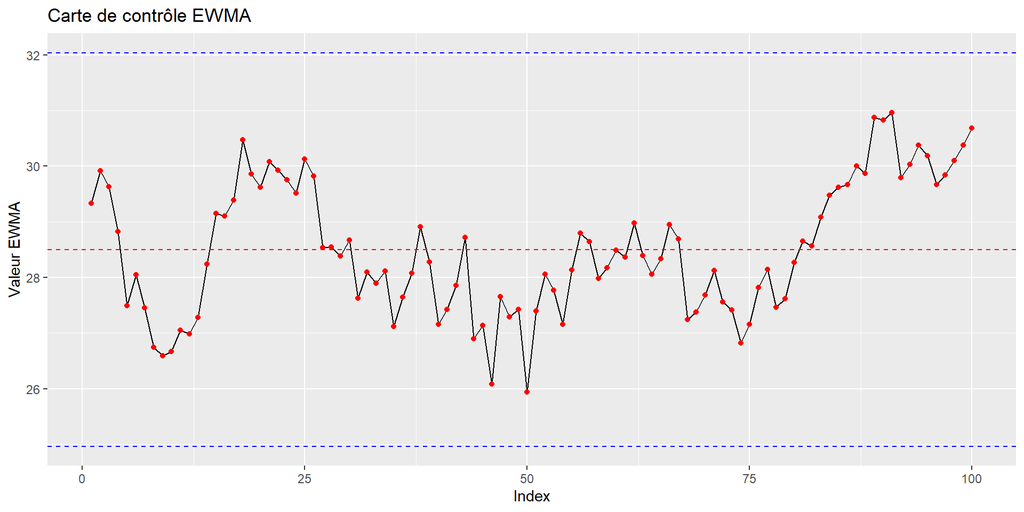

```r
# Paramètres
lambda <- 0.15
n <- length(data5)

ewma <- numeric(n)
ewma[1] <- data5[1]

for (i in 2:n) {
  ewma[i] <- lambda * data5[i] + (1 - lambda) * ewma[i - 1]
}

# Calcul des limites de contrôle
sigma <- sd(data5)
ucl <- mean(ewma) + 3 * sigma * sqrt(lambda / (2 - lambda))
lcl <- mean(ewma) - 3 * sigma * sqrt(lambda / (2 - lambda))

df_ewma <- data.frame(Index = 1:n, EWMA = ewma)

ggplot(df_ewma, aes(x = Index, y = EWMA)) +
  geom_line(color = "black") +
  geom_point(color = "red") +
  geom_hline(yintercept = mean(ewma), color = "red", linetype = "dashed") +
  geom_hline(yintercept = ucl, color = "blue", linetype = "dashed") +
  geom_hline(yintercept = lcl, color = "blue", linetype = "dashed") +
  ggtitle("Carte de contrôle EWMA") +
  xlab("Index") +
  ylab("Valeur EWMA")
```

Toutes les valeurs restent à l’intérieur des limites de contrôle, mais la croissance vers la fin du graphique peut être le signe d’une dérive à surveiller.

**Question 5** : Carte de contrôle EWMA avec la ligne centrale mobile

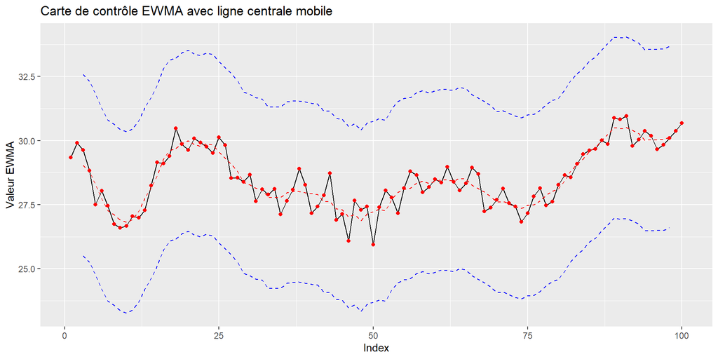

```r
# Paramètres
lambda <- 0.15
n <- length(data5)
ewma <- numeric(n)
ewma[1] <- data5[1]

for (i in 2:n) {
  ewma[i] <- lambda * data5[i] + (1 - lambda) * ewma[i - 1]
}

# Calcul de la ligne centrale mobile (moyenne mobile sur une fenêtre de 5)
taille_fenetre <- 5
ligne_centrale <- filter(ewma, rep(1/taille_fenetre, taille_fenetre), sides=2)

# Calcul des limites de contrôle
sigma <- sd(data5)
ucl <- ligne_centrale + 3 * sigma * sqrt(lambda / (2 - lambda))
lcl <- ligne_centrale - 3 * sigma * sqrt(lambda / (2 - lambda))

df_ewma <- data.frame(Index = 1:n, EWMA = ewma, LigneCentrale = ligne_centrale)

ggplot(df_ewma, aes(x = Index, y = EWMA)) +
  geom_line(color = "black") +
  geom_point(color = "red") +
  geom_line(aes(y = LigneCentrale), color = "red", linetype = "dashed") +
  geom_line(aes(y = ucl), color = "blue", linetype = "dashed") +
  geom_line(aes(y = lcl), color = "blue", linetype = "dashed") +
  ggtitle("Carte de contrôle EWMA avec ligne centrale mobile") +
  xlab("Index") +
  ylab("Valeur EWMA")
```

Cette carte avec la ligne centrale mobile permet une meilleure réactivité face aux changements progressifs, contrairement à une carte EWMA classique.

**Question 6** :

Un processus auto-régressif d’ordre 2 AR(2) signifie que chaque observation dépend linéairement des deux observations précédentes, selon l’équation suivante :

$$X_t = \Phi_1 X_{t-1} + \Phi_2 X_{t-2} + \varepsilon_t$$

où $\varepsilon_t$ est un bruit blanc gaussien.

Dans un contrôle de procédé, l’auto-corrélation temporelle peut fausser les cartes de contrôle classiques (CUSUM ou EWMA). On peut modéliser et supprimer l’auto-corrélation, puis à analyser les résidus du modèle AR(2), qui sont supposés être indépendants et normalement distribués. L’objectif du modèle AR(2) est de capturer la dépendance temporelle et de générer des résidus supposés indépendants.

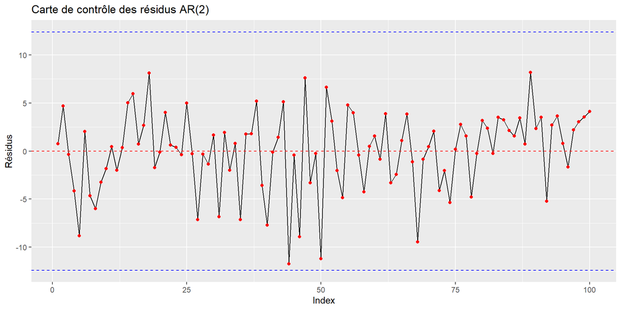

```r
# modèle AR(2) appliqué à nos données
modele_ar2 <- arima(data5, order = c(2,0,0))

# extraction des résidus
residus <- residuals(modele_ar2)
residus <- as.numeric(residuals(modele_ar2)) # conversion en vecteur numérique

# Carte de contrôle des résidus
moy_residus <- mean(residus)
ectype_residus <- sd(residus)

ucl <- moy_residus + 3 * ectype_residus
lcl <- moy_residus - 3 * ectype_residus

df_residus <- data.frame(Index = 1:length(residus), Residus = residus)

ggplot(df_residus, aes(x = Index, y = Residus)) +
  geom_line(color = "black") +
  geom_point(color = "red") +
  geom_hline(yintercept = moy_residus, color = "red", linetype = "dashed") +
  geom_hline(yintercept = ucl, color = "blue", linetype = "dashed") +
  geom_hline(yintercept = lcl, color = "blue", linetype = "dashed") +
  ggtitle("Carte de contrôle des résidus AR(2)") +
  xlab("Index") +
  ylab("Résidus")
```

La majorité des résidus oscillent autour de la moyenne et restent à l’intérieur des limites de contrôle, ce qui indique que le procédé est sous contrôle statistique et qu’aucune dérive significative n’est détectée. Visuellement, cette carte ne diffère pas beaucoup des précédentes (hors carte à ligne centrale mobile). Ceci peut être du au fait que l’auto-corrélation dans les données initiales était faible, alors on peut penser que la transformation via AR(2) n’altère pas radicalement le rendu graphique.